# Figure 1

Jaime So

2025-07-30

# Figure 1: Library Design and PhIP-Seq Methodology.

The Pan-VSG phage display library contains 90AA peptide tiles that overlap by 45 AA and includes sequence from 12,108 VSG genes and pseudogenes. 300-mer DNA oligos encoding each peptide synthesized and cloned into T7 phage display vector. Library is incubated with serum and bound phages immunocaptured using protein A/G coated magnetic beads then sequenced.

# B

## Load Data

```r
# Simplify output so all A1 subtypes are just A1 so plot isn't too busy
VSG_info <- read_csv("FigureData/VSG_Tile_Classification.csv") %>%
  mutate(VSG_class = case_when(nterm_typesubtype == "1a" ~ "A1",
                               nterm_typesubtype == "1b" ~ "A1",
                               nterm_typesubtype == "1c" ~ "A1",
                               HMM_profile == "VSG-N-TypeB" | nterm_typesubtype == "B1" ~ "B",
                               TRUE ~ .$nterm_typesubtype))
# VSG species and strain of origin info
VSG_accession <- read_csv("FigureData/Library_VSG_reference.csv")
```

## Library

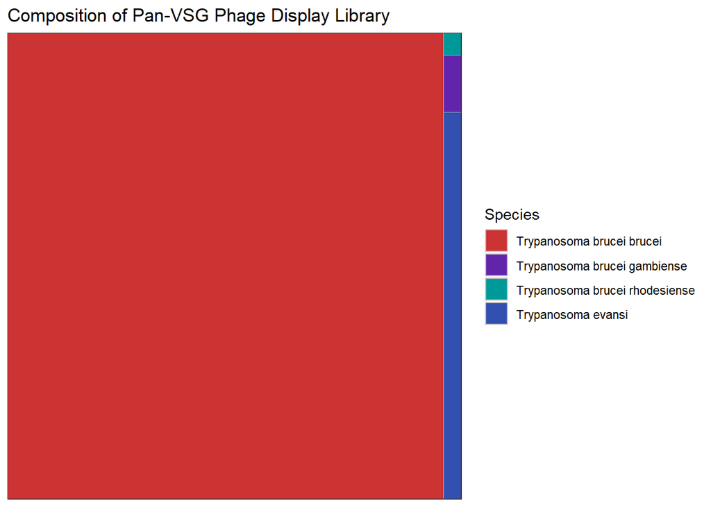

```r
# Plotting TreeMap Graph
VSG_accession %>% group_by(Species) %>% summarise(n = n()) %>%
  ggplot(aes(area=n,fill=Species,label=Species))+
  treemapify::geom_treemap(layout="squarified")+
  #geom_treemap_text(place = "centre",size = 16)+
  scale_fill_manual(values = c("#cc3333", "#6224aa", "#009999", "#3150af"))+
  labs(title="Composition of Pan-VSG Phage Display Library")
```

```r
# merge with typing data to add these to plot breakdown
strain_info <- left_join(VSG_info %>% select(pro_id, VSG_class) %>% distinct(), VSG_accession, by = c("pro_id"= "GB_Accession/TriTrypDB"))
VSG_accession %>% group_by(Species) %>% summarise(n = n())
```

```
## # A tibble: 4 × 2
##   Species                            n
##   <chr>                          <int>
## 1 Trypanosoma brucei brucei      11632
## 2 Trypanosoma brucei gambiense      58
## 3 Trypanosoma brucei rhodesiense    23
## 4 Trypanosoma evansi               395
```

## brucei

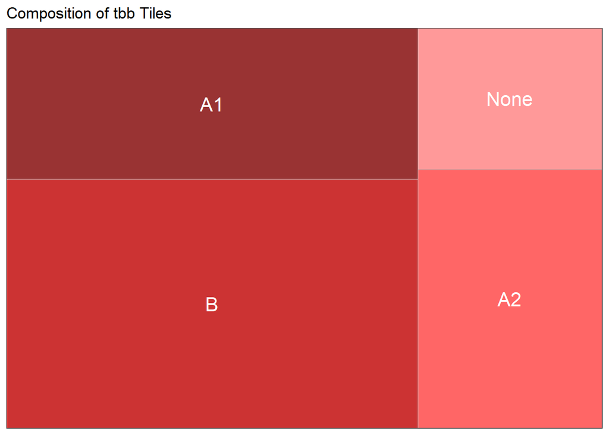

```r
tb_type <- strain_info %>% filter(Species == "Trypanosoma brucei brucei") %>% group_by(VSG_class) %>% summarise(n = n())
tb_type$VSG_class <- replace(tb_type$VSG_class, (tb_type$VSG_class == "Indeterminate"), values = c("None"))

tb_type %>%
  ggplot(aes(area=n,fill=VSG_class,label=VSG_class))+
  treemapify::geom_treemap(layout="squarified")+
  geom_treemap_text(place = "centre",size = 16, color = "white")+
  scale_fill_manual(values = c("#993333", "#ff6666", "#cc3333", "#ff9999"))+
  theme(legend.position = "none")+
  labs(title="Composition of tbb Tiles")
```

```r
tb_type
```

```
## # A tibble: 4 × 2
##   VSG_class     n
##   <chr>     <int>
## 1 A1         3033
## 2 A2         2334
## 3 B          4996
## 4 None       1269
```

## gambiense

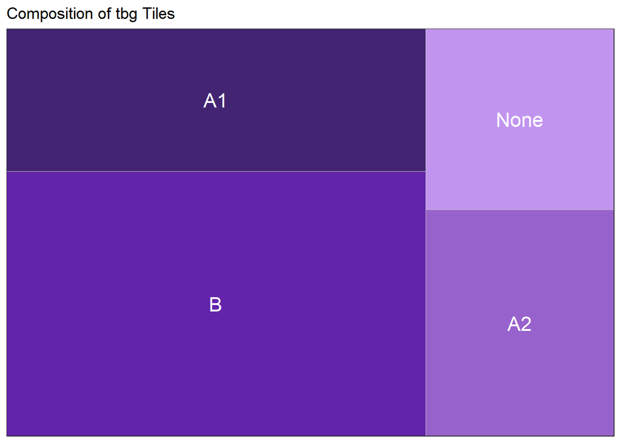

```r
tbg_type <- strain_info %>% filter(Species == "Trypanosoma brucei gambiense") %>% group_by(VSG_class) %>% summarise(n = n())
tbg_type$VSG_class <- replace(tbg_type$VSG_class, tbg_type$VSG_class == "Indeterminate", values = c("None"))

tbg_type %>%
  ggplot(aes(area=n,fill=VSG_class,label=VSG_class))+
  treemapify::geom_treemap(layout="squarified")+
  geom_treemap_text(place = "centre",size = 16, color = "white")+
  scale_fill_manual(values = c("#422472", "#9862cc", "#6224aa", "#c195ef"))+
  theme(legend.position = "none")+
  labs(title="Composition of tbg Tiles")
```

```r
tbg_type
```

```
## # A tibble: 4 × 2
##   VSG_class     n
##   <chr>     <int>
## 1 A1           14
## 2 A2           10
## 3 B            26
## 4 None          8
```

## evansi

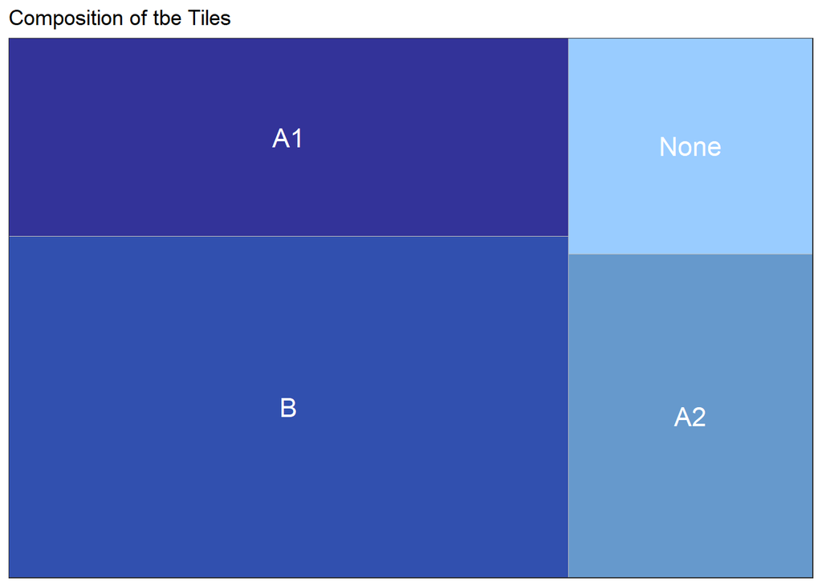

```r
tbe_type <- strain_info %>% filter(Species == "Trypanosoma evansi") %>% group_by(VSG_class) %>% summarise(n = n())
tbe_type$VSG_class <- replace(tbe_type$VSG_class, tbe_type$VSG_class == "Indeterminate", values = c("None"))

tbe_type %>%
  ggplot(aes(area=n,fill=VSG_class,label=VSG_class))+
  treemapify::geom_treemap(layout="squarified")+
  geom_treemap_text(place = "centre",size = 16, color = "white")+
  scale_fill_manual(values = c("#333399", "#6699cc", "#3150af", "#99ccff"))+
  theme(legend.position = "none")+
  labs(title="Composition of tbe Tiles")
```

```r
tbe_type
```

```
## # A tibble: 4 × 2
##   VSG_class     n
##   <chr>     <int>
## 1 A1          101
## 2 A2           72
## 3 B           174
## 4 None         48
```

## rhodesiense

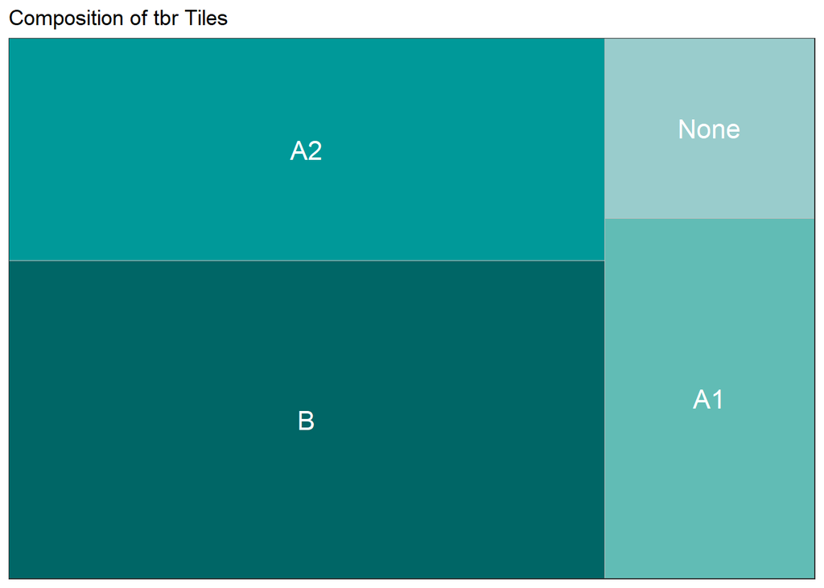

```r
tbr_type <- strain_info %>% filter(Species == "Trypanosoma brucei rhodesiense") %>% group_by(VSG_class) %>% summarise(n = n())
tbr_type$VSG_class <- replace(tbr_type$VSG_class, tbr_type$VSG_class == "Indeterminate", values = c("None"))

tbr_type %>%
  ggplot(aes(area=n,fill=VSG_class,label=VSG_class))+
  treemapify::geom_treemap(layout="squarified")+
  geom_treemap_text(place = "centre",size = 16, color = "white")+
  scale_fill_manual(values = c("#61bcb5", "#009999", "#006666", "#99cccc"))+
  theme(legend.position = "none")+
  labs(title="Composition of tbr Tiles")
```

```r
tbr_type
```

```
## # A tibble: 4 × 2
##   VSG_class     n
##   <chr>     <int>
## 1 A1            4
## 2 A2            7
## 3 B            10
## 4 None          2
```

# C

```r
# perform preliminary library QC
### generate lists of missing peptides, summary statistics, and a histogram showing read count distribution
# 1. lib.regex = regex to recognize a library count file (ex. "library_.+trimmed.fq.sorted.bam.htseq.txt")
# 2. directory = directory where to find library count files and also write output

library.qc <- function(lib.regex, directory){
  #Install/load packages
  if (system.file(package = "tidyverse") == "") install.packages("tidyverse")
  if (is.null(sessionInfo()$otherPkgs$tidyverse)) library(tidyverse)

  #Read in files of library counts
  libs <- list.files(directory)[grepl(lib.regex, list.files(directory))]
  for (i in 1:length(libs)){
    lib.i <- read.table(paste(directory, libs[i], sep = "/"), header = F, comment.char = "_")
    if (i == 1) count_matrix_lib <- lib.i else count_matrix_lib <- left_join(count_matrix_lib, lib.i, by = "X1")
  }

  #Filter for peptides (counts files have bowtie info at the bottom)
  count_matrix_lib <- count_matrix_lib %>% column_to_rownames(var = "V1")

  # Concatenate library input samples and calculate/include log10 of read counts
  library_cat <- data.frame(pep_id = rownames(count_matrix_lib), Reads = rowSums(count_matrix_lib)) %>%
    mutate(logReads = case_when(Reads != 0 ~ log10(Reads)))

  # How many library members were detected
  n_library <- nrow(library_cat)
  n_detected <- sum(library_cat$Reads > 0)
  pct_detected <- round(n_detected/n_library*100, digits = 2)

  # Get represented tiles and how many are within 1 log abundance
  not_missing <- library_cat %>% filter(Reads != 0)

  # Generate 1 log abundance intervals
  log_max <- max(not_missing$logReads)
  log_min <- min(not_missing$logReads)
  n <- length(not_missing$logReads)/10
  intervals <- data.frame(
    i_min = c(0:(n-1))*(log_max-1)/n,
    i_max = c(0:(n-1))*(log_max-1)/n+1) %>%
    mutate(c_min = round(10^i_min), c_max = round(10^i_max))
  # Find 1 log abundance interval with largest area
  intervals$n_pep <- apply(intervals, 1, function(x) sum(not_missing$logReads > x[1] & not_missing$logReads < x[2]))
  one_log <- max(intervals$n_pep)
  pct_log <- round(one_log/nrow(not_missing)*100,2)
  m_low <- min(intervals$c_min[intervals$n_pep == one_log])
  m_high <- max(intervals$c_max[intervals$n_pep == one_log])

  # Make file of all members
  all_members <- library_cat %>%
    mutate(status = case_when(Reads == 0 ~ "Missing", (Reads < m_low) & (Reads > 0) ~ "Underrepresented", TRUE ~ "Represented"))
  write.csv(all_members, file = paste(directory, "library_representation.csv", sep = "/"), quote = FALSE)

  # Make qc summary file
  lines <- c("Library Peptide QC Summary",
             paste0(n_detected, " of ", n_library, " (", pct_detected, "%) peptides detected."),
             paste0(one_log, " of ", nrow(not_missing), " (", pct_log, "%) detected peptides were within one log abundance (", m_low, "-", m_high,")."))
  print(lines)
  writeLines(lines, paste(directory, "library_qc_summary.txt", sep = "/"))

  # Plot distribution
  print(
    not_missing %>%
      ggplot(aes(x = Reads))+
      geom_histogram(fill = "#1177BB", color = "black")+
      scale_x_log10()+
      geom_vline(xintercept = m_low, lty = 2, color = "red")+
      geom_vline(xintercept = m_high, lty = 2, color = "red")+
      ylab("Frequency")+
      theme_bw()
  )
  ggsave(paste(directory, "library_qc_histogram.pdf", sep = "/"))
}

library.qc(lib.regex = "lib_ctl", directory = "FigureData/LibraryInputCTLs/")
```

[output not shown]

Function creates 3 files: * library_qc_histogram.pdf - histogram of detected library reads per peptide * library_qc_summary.txt - contains proportions of peptide tiles detected * library_representation.csv - record of which tiles are represented, underrepresented, or undetected

By [Jaime So](https://github.com/JSoSci/) for the [Mugnier Lab](https://www.mugnierlab.org/)

*jso4@jhmi.edu*